## 1. Introducción y Carga de Datos

En este laboratorio realizamos la descomposición de una serie temporal en sus componentes principales: **tendencia (baja frecuencia)**, **ciclos (frecuencia intermedia)** y **ruido (alta frecuencia)** utilizando filtros de Media Móvil (MA) y la Transformada Rápida de Fourier (FFT).

```r
# Configuración de ruta y lectura
archivo <- paste0("TS_1.csv")

if (file.exists(archivo)) {
  dato <- read.csv(archivo)
  print(paste("Columnas cargadas:", paste(names(dato), collapse = ", ")))
} else {
  stop("El archivo TS_1.csv no se encuentra en la ruta especificada.")
}
```

```
## [1] "Columnas cargadas: X, t, a0, a1, a2, rn, a"
```

## 2. Visualización de las Componentes Originales

Graficamos primero las componentes ideales que componen nuestra señal `a`.

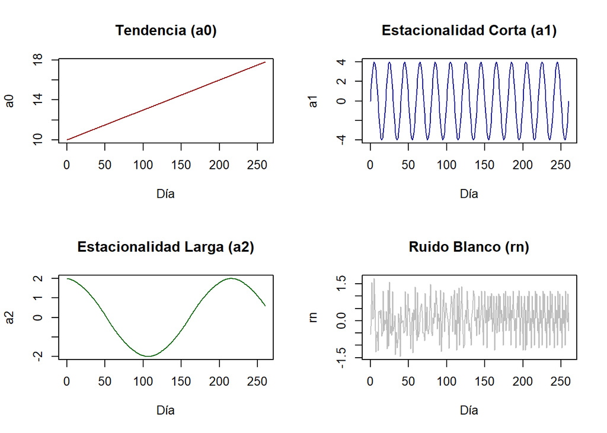

```r
par(mfrow = c(2, 2))
plot(dato$t, dato$a0, type='l', main="Tendencia (a0)", xlab='Día', ylab='a0', col="darkred")
plot(dato$t, dato$a1, type='l', main="Estacionalidad Corta (a1)", xlab='Día', ylab='a1', col="darkblue")
plot(dato$t, dato$a2, type='l', main="Estacionalidad Larga (a2)", xlab='Día', ylab='a2', col="darkgreen")
plot(dato$t, dato$rn, type='l', main="Ruido Blanco (rn)", xlab='Día', ylab='rn', col="gray")
```

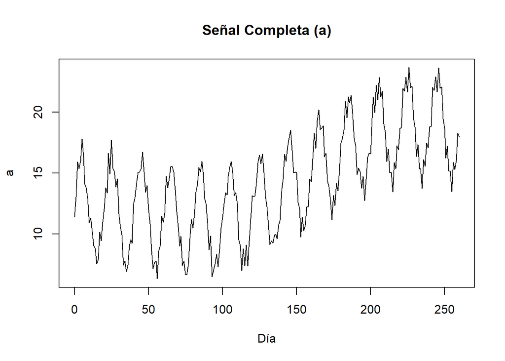

```r
par(mfrow = c(1, 1))
plot(dato$t, dato$a, type='l', main="Señal Completa (a)", xlab='Día', ylab='a')
```

## 3. Descomposición con Filtros de Media Móvil (MA)

Aplicamos filtros pasabajos sucesivos para aislar las componentes. El filtro MA suaviza la señal promediando los valores en una ventana de tiempo.

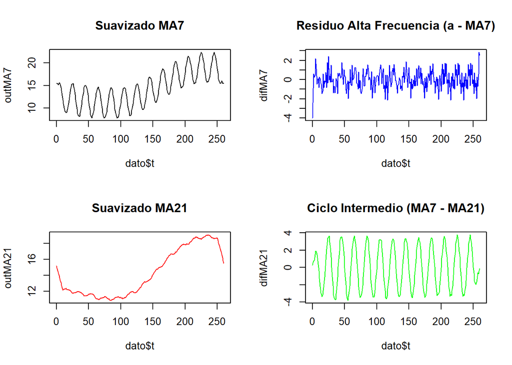

```r
# MA7: Filtro de ventana corta (1 semana)
outMA7 <- filter(dato$a, rep(1/7, 7), circular = TRUE)
difMA7 <- dato$a - outMA7 # Alta frecuencia extraída

# MA21: Filtro de ventana larga (3 semanas)
outMA21 <- filter(dato$a, rep(1/21, 21), circular = TRUE)
difMA21 <- outMA7 - outMA21 # Frecuencia intermedia extraída

# Visualización del proceso de filtrado
par(mfrow = c(2, 2))
plot(dato$t, outMA7, type='l', col="black", main="Suavizado MA7")
plot(dato$t, difMA7, type='l', col="blue", main="Residuo Alta Frecuencia (a - MA7)")
plot(dato$t, outMA21, type='l', col="red", main="Suavizado MA21")
plot(dato$t, difMA21, type='l', col="green", main="Ciclo Intermedio (MA7 - MA21)")
```

### Superposición en el Dominio del Tiempo

Comparamos cómo se sitúan las componentes extraídas respecto a la señal suavizada original.

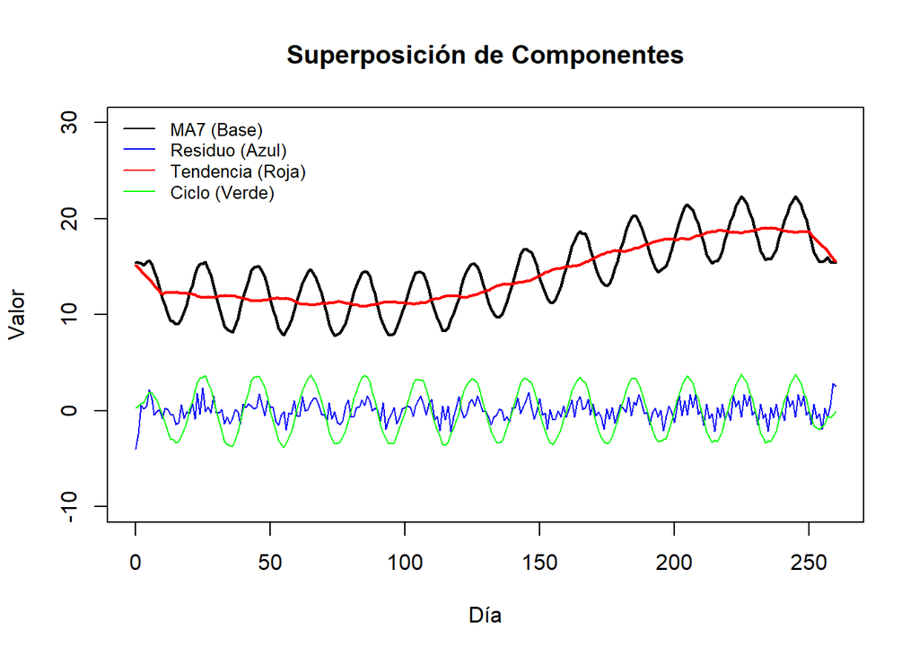

```r
# Configuración para un solo gráfico
par(mfrow = c(1, 1))

# Gráfico principal (MA7 como base)
plot(dato$t, outMA7, type='l', ylim=c(-10, 30),
     xlab='Día', ylab='Valor',
     main="Superposición de Componentes",
     col='black', lwd=2)

# Agregamos las líneas de las demás componentes
lines(dato$t, difMA7, col='blue')    # Ruido (Alta frecuencia)
lines(dato$t, outMA21, col='red', lwd=2)   # Tendencia (Baja frecuencia)
lines(dato$t, difMA21, col='green') # Estacionalidad (Frecuencia intermedia)

legend("topleft",
       legend = c("MA7 (Base)", "Residuo (Azul)", "Tendencia (Roja)", "Ciclo (Verde)"),
       col = c("black", "blue", "red", "green"),
       lty = 1,
       bty = "n",
       cex = 0.8)
```

## 4. Análisis en el Dominio de la Frecuencia (FFT)

Utilizamos la **Fast Fourier Transform** para observar el espectro de potencias. Esto nos permite validar que los filtros están actuando sobre los rangos de frecuencia correctos.

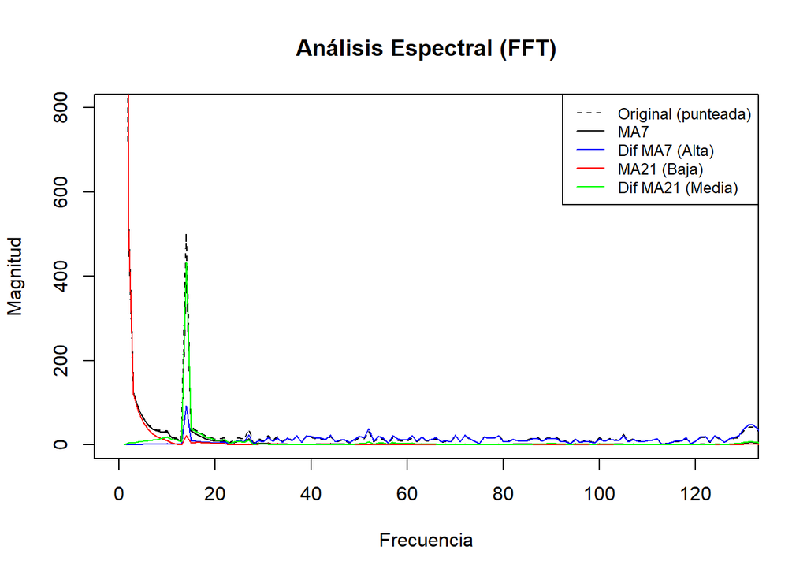

```r
# Cálculo de magnitudes
fft.a <- Mod(fft(dato$a))
fft.outMA7 <- Mod(fft(outMA7))
fft.difMA7 <- Mod(fft(difMA7))
fft.outMA21 <- Mod(fft(outMA21))
fft.difMA21 <- Mod(fft(difMA21))

# Gráfico del Espectro
plot(fft.a, type='l', col='black', lty=2, ylim=c(0, 800), xlim=c(0, 128),
     main="Análisis Espectral (FFT)", xlab="Frecuencia", ylab="Magnitud")

lines(fft.outMA7, col='black')
lines(fft.difMA7, col='blue')
lines(fft.outMA21, col='red')
lines(fft.difMA21, col='green')

legend("topright", legend=c("Original (punteada)", "MA7", "Dif MA7 (Alta)", "MA21 (Baja)", "Dif MA21 (Media)"),
       col=c("black", "black", "blue", "red", "green"), lty=c(2, 1, 1, 1, 1), cex=0.8)
```

Fin del informe - Procesamiento de Señales

### ¿Cómo lo ejecuto?

1. En RStudio, hacé clic en el botón **“Knit”** (el ícono del ovillo de lana) arriba de todo.
2. Elegí **“Knit to HTML”**.
3. R va a procesar todo y te va a abrir una ventana con un reporte limpio, con tablas de contenido navegables y los gráficos incrustados.